# De Benedictis project

Alberto De Benedictis

2026-02-09

# 7. Relationship of the percentage of identity in the full 16s gene with respect to identity calculated on parts of the gene.

16S rRNA is widely used for bacteria taxonomy, using a 97% identity threshold for differentiating species. In particular V3-V4 regions are considered hypervariable, and often used for the aforementioned scope, instead of the full sequence. The aim of this analysis is investigating the variability of this region as opposed to the entirety of the sequence, verifying that the 97% threshold holds the same significance for V3-V4 and the full gene. If the region is really more diverse, the current threshold would need to be adjusted to avoid overestimation of the real diversity. The pipeline to address this aligns a subsample of the given sequences, calculates the pairwise identities of both full-length genes and V3-V4 regions, and uses linear regression to test the null hypothesis that beta=1, meaning that the V3-V4 region is changing at the exact same rate as the rest of the gene, indicating a new identity threshold for the region.

```r
library(seqinr)
library(car)
library(ape)
# 1. ALIGNMENT

# Aligmnent with mafft
system("mafft --adjustdirection --auto --quiet expert_RDP.fas > aligned_16S.fasta")

alignment<- read.alignment("aligned_16S.fasta", format = "fasta")

set.seed(43)
indices <- sample(1:alignment$nb, 1000)
alignment_sampled <- list(
  nb  = 1000,
  nam = alignment$nam[indices],
  seq = alignment$seq[indices],
  com = NA
)
class(alignment_sampled) <- "alignment"

alignment_matrix<- as.matrix.alignment(alignment_sampled)

cat("Alignment Loaded. Total Sequences:", alignment_sampled$nb, "\n")
```

```
## Alignment Loaded. Total Sequences: 1000
```

The dist.alignment function calculates pairwise distances based on the identity matrix, with the resulting distance D=√(1-identity)

```r
# 2. CALCULATING IDENTITIES
# Calculating distance and converting to identity vectors
dist_full<- seqinr::dist.alignment(alignment_sampled, matrix = "identity")
vec_full_id<- 1 - (as.vector(dist_full))^2
```

The extraction of V3-V4 was the most delicate part of the project. A gap-tolerant expression for the primers was implemented and the aligned sequences were scanned for a valid reference sequence that contained both primers. Then its start and end coordinates were used to slice the entire alignment matrix.

```r
# 3. SLICING V3-V4
# Defining the regex for primers, accounting for alignment gaps
make_gap_regex<- function(motif) paste(strsplit(motif, "")[[1]], collapse = "-*")
v3_motif<- make_gap_regex("CCTACGGGAG")
v4_motif <- make_gap_regex("ATTAGATACC")

# Searching through E. coli sequences until we find a perfect match
start_col<- NA
end_col<- NA
best_ref<- NA

for (i in length(alignment_sampled$nb)) {
  # Extractin the string for this specific sequence
  current_seq<- toupper(paste(alignment_matrix[i, ], collapse = ""))

  # Checking for primers
  s_match<- regexpr(v3_motif, current_seq)
  e_match<- regexpr(v4_motif, current_seq)

  # Assigning coordinates once the match is found
  if (s_match != -1 && e_match != -1) {
    start_col<- as.numeric(s_match)
    end_col<- as.numeric(e_match) + attr(e_match, "match.length") - 1
    best_ref<- i

    cat("V3 Start Col:", start_col, "\nV4 End Col:", end_col, "\n")
    break
  }
}
```

```
## V3 Start Col: 831
## V4 End Col: 1514
```

```r
# Slicing the matrix, cutting everyone by the coordinates obtained
v_region_mat<- alignment_matrix[, start_col:end_col]

# Creating the new alignment object
alignment_v3v4<- list(
  nb  = alignment_sampled$nb,
  nam = alignment_sampled$nam,
  seq = apply(v_region_mat, 1, paste, collapse=""),
  com = NA
)
class(alignment_v3v4)<- "alignment"

# Verification
cat("\nCHECKING SLICE ON ANCHOR SEQUENCE:\n")
```

```
##
## CHECKING SLICE ON ANCHOR SEQUENCE:
```

```r
anchor_seq<- alignment_v3v4$seq[best_ref]
cat("Start (Should be CCTACGGGAG...): ", substr(anchor_seq, 1, 15), "\n")
```

```
## Start (Should be CCTACGGGAG...):  cctacggga-ggc-a
```

```r
cat("End   (Should be ...ATTAGATACC): ", substr(anchor_seq, nchar(anchor_seq)-14, nchar(anchor_seq)), "\n")
```

```
## End   (Should be ...ATTAGATACC):  a--tt-aga-ta-cc
```

```r
# 4. CALCULATE REGION IDENTITIES
# Partial (V3-V4) identity
dist_v3v4<- seqinr::dist.alignment(alignment_v3v4, matrix = "identity")
vec_v3v4_id<- 1 - (as.vector(dist_v3v4))^2
```

Linear regression predicts the similarity of the overall gene similarities based on the V3-V4 region similarities, comparing a model with no intercept with a model with intercept.

```r
# 5. REGRESSION
# Filtering the sequences with at least 90% identity
threshold_filter<- 0.9

valid_indices<- which(vec_full_id > threshold_filter & vec_v3v4_id > threshold_filter)

# Creating two columns in the data frame, the first for the similarity the whole gene
# and the second for the V3-V4 region
df<- data.frame(
  full = vec_full_id[valid_indices],
  partial = vec_v3v4_id[valid_indices]
)

# Standard Linear Model with intercept
model_lm<- lm(full ~ partial, data = df)

# Standard Linear Model without intercept
model_lm_noint<- lm(full ~ partial + 0, data = df)

cat("\nAIC with intercept:", AIC(model_lm), "\n")
```

```
##
## AIC with intercept: -214934.4
```

```r
cat("\nAIC without intercept:", AIC(model_lm_noint), "\n")
```

```
##
## AIC without intercept: -214866
```

```r
best_model<- if (AIC(model_lm) < AIC(model_lm_noint)) model_lm else model_lm_noint

if (AIC(model_lm) < AIC(model_lm_noint)) cat("\nThe model with the intercept is better.") else cat("\nThe model with no intercept is better.\n")
```

```
##
## The model with the intercept is better.
```

```r
summary<- summary(best_model)
print(summary)
```

```
##
## Call:
## lm(formula = full ~ partial, data = df)
##
## Residuals:
##       Min        1Q    Median        3Q       Max
## -0.047525 -0.006177  0.000093  0.005319  0.051214
##
## Coefficients:
##             Estimate Std. Error t value Pr(>|t|)
## (Intercept) 0.016587   0.001976   8.392   <2e-16 ***
## partial     0.980743   0.002086 470.060   <2e-16 ***
## ---
## Signif. codes:  0 '***' 0.001 '**' 0.01 '*' 0.05 '.' 0.1 ' ' 1
##
## Residual standard error: 0.01195 on 35726 degrees of freedom
## Multiple R-squared:  0.8608, Adjusted R-squared:  0.8608
## F-statistic: 2.21e+05 on 1 and 35726 DF,  p-value: < 2.2e-16
```

Calculating the Log2 helps visualize the bias between the two metrics. A ratio of 0 means that full agreement, while its distance from zero shows how much the V3-V4 region indices vary from the full gene indices.

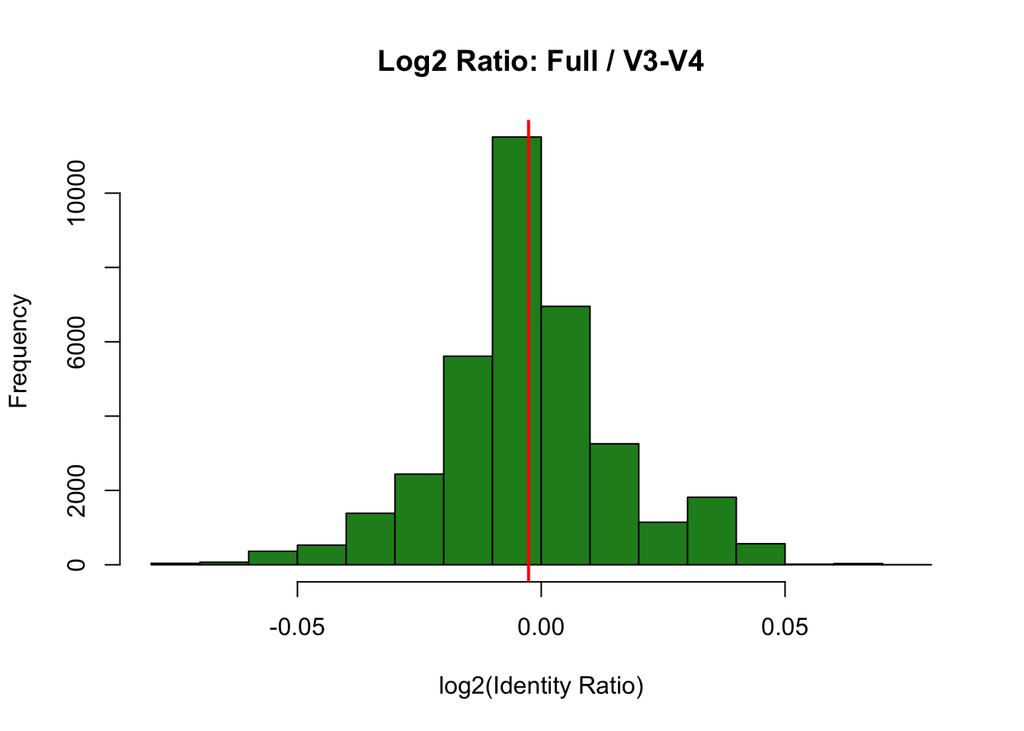

```r
# 6. Log2 ratio Visualisation
log_ratio<- log2(df$full / df$partial)
df$log_ratio<-log_ratio
mean_l2<-mean(log_ratio)

# Creating a plot that shows the spread of the error
hist(df$log_ratio, col="forestgreen",
     main=paste("Log2 Ratio: Full / V3-V4"),
     xlab="log2(Identity Ratio)")
abline(v = mean_l2, col = "red", lwd = 2)
```

```r
# 7. OUTPUT SUMMARY
beta<- coef(model_lm)[2]
intercept<- coef(model_lm)[1]

# Test the Null Hypothesis: H0: beta = 1
hyp_test<- linearHypothesis(model_lm, "partial = 1")
p_val<- hyp_test$`Pr(>F)`[2]

#Treshold to use on V3-V4 data to be congruent with a 97% threshold
# Formula<- 0.97=beta*(Target_V3V4)+intercept
target_threshold<- (0.97 -intercept) /beta

cat("\nSTANDARD LINEAR REGRESSION RESULTS\n")
```

```
##
## STANDARD LINEAR REGRESSION RESULTS
```

```r
cat("Slope (Beta):", beta, "\n")
```

```
## Slope (Beta): 0.9807429
```

```r
cat("Standard Error of Beta:", summary$coefficients[2,2], "\n")
```

```
## Standard Error of Beta: 0.002086421
```

```r
cat("Is beta significantly different from 1.0?")
```

```
## Is beta significantly different from 1.0?
```

```r
if(p_val < 0.05) {
  cat(" TRUE\n")
  cat("To be congruent with a 97% Full-Gene threshold, use a V3-V4 threshold of:",
  round(target_threshold * 100, 2))
} else {
  cat(" FALSE\n")
}
```

```
##  TRUE
## To be congruent with a 97% Full-Gene threshold, use a V3-V4 threshold of: 97.21
```

Standard linear regression conclusions: the V3-V4 region is known as a hypervariable region of 16s, so the expected result would be a beta significantly lower than one, indicating a higher rate of change compared to the full region. This is precisely the result obtained, since beta is significantly lower than one. Because the regression slope is slightly below 1, the mapping between V3–V4 and Full-Gene identity is flatter than the identity line (y = x). As a result, achieving 97% Full-Gene identity requires a slightly higher V3–V4 identity threshold.